# Презентация по лабораторной работе №2

Структура данных

Люпп Софья Романовна

1132236039@rudn.ru

Российский университет дружбы народов

2026-09-24

# Информация

## Докладчик

- Люпп Софья Романовна
- студентка группы НКНбд-01-23
- кафедра теории вероятностей и кибербезопасности
- Российский университет дружбы народов им. П. Лумумбы
- [1132236039@rudn.ru]
- https://github.com/srluipp

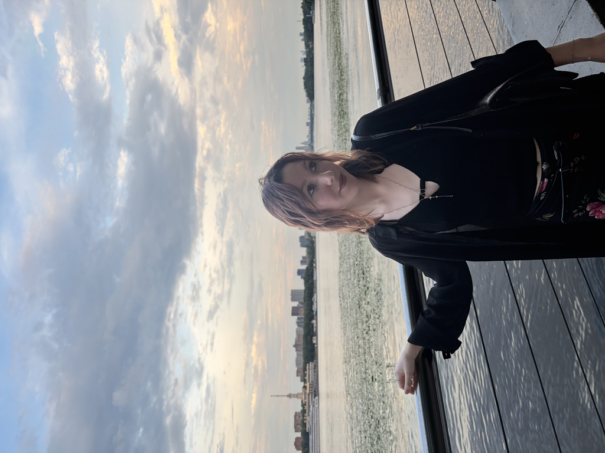

# Вводная часть

## Актуальность

Julia актуальна как инструмент для научных вычислений, финансового моделирования, искусственного интеллекта, вычислений в области инженерии и физики, благодаря своей высокой производительности, простоте синтаксиса и гибкости в работе с массивами и параллельным программированием

## Объект и предмет исследования

Язык программирования Julia и среда JupyterLab

## Цели и задачи

Основная цель работы — изучить несколько структур данных, реализованных в Julia, научиться применять их и операции над ними для решения задач.

# Выполнение лабораторной работы

Начинаю с подготовки и настройки рабочего пространства (установка JupyterLab с выбранным языком программирования Julia),(рис. 1).

[figure not shown]

Рисунок 1: JupyterLab

## Задания лабораторной работы

Начинаю поэтапно выполнять задания лабораторной работы. Для задания №1 нахожу пересечения множество с помощью оператора Set()(рис. 2)

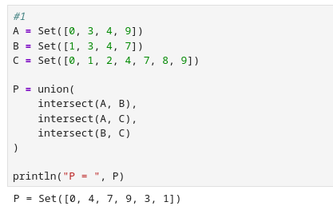

Рисунок 2: Set

## Задание 2

Далее привожу свои примеры операций над множествами элементов разных типов (рис. 3)

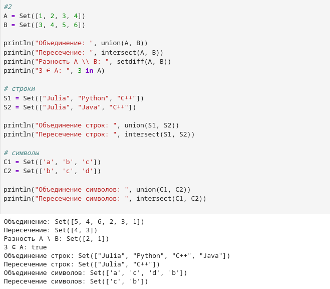

Рисунок 3: задание 2

## Методы isempty(), reduce(), minimum() и другие

Привожу пример исполнения метода isempty(), reduce(), minimum() и других методов, создав массивы для каждого метода и выводя получившиеся результаты(рис. 4)

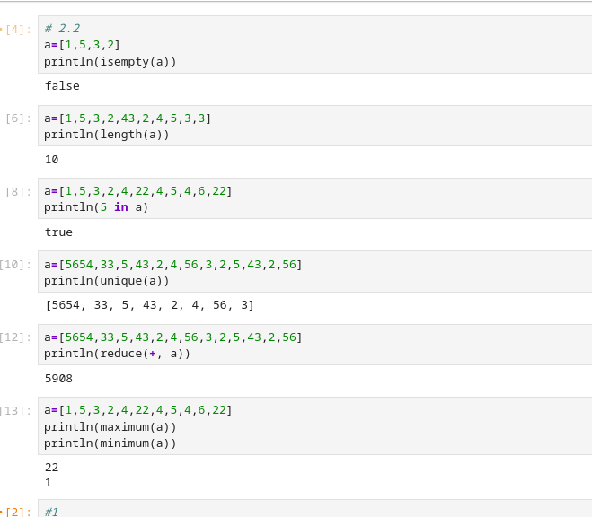

Рисунок 4: структуры данных

## Задание №3

Выполняю задание 3.1, где вывожу вектор, состоящий из последовательных значений от 1 до 25 (рис. 5).

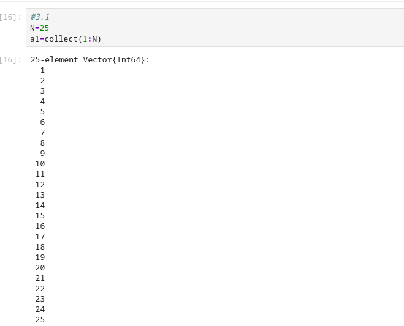

Рисунок 5: 3.1

## 3.2

Вывожу тот же вектор только со значениями, заданными в обратной последовательности (рис. 6)

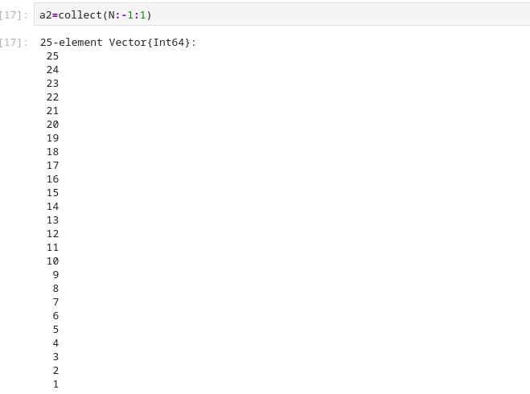

Рисунок 6: 3.2

## 3.3

При помощи collect() создаю вектор со значениями от 1 до 25 и обратно, от 24 до 1 (рис. Рисунок 7])

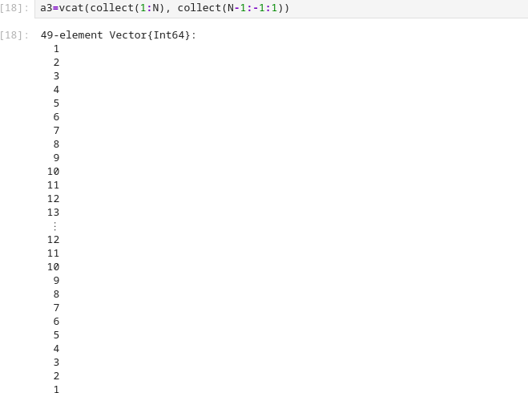

Рисунок 7: 3.3

## 3.4

Создаю вектор tmp с заданными значениями (рис. 8).

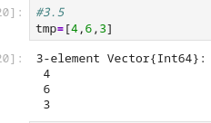

Рисунок 8: 3.4

## 3.5

Повторяю первую компоненту вектора tmp 10 раз (рис. 9).

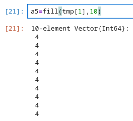

Рисунок 9: 3.5

## 3.6

Повторяю все элементы вектора tmp 10 раз(рис. 10)

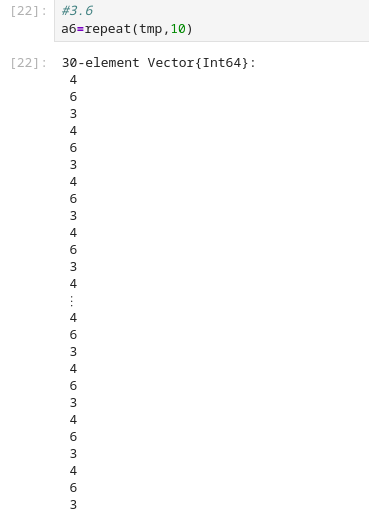

Рисунок 10: 3.6

## 3.7

Повтряю каждое из значений вектора tmp некоторое количество раз(рис. 11)

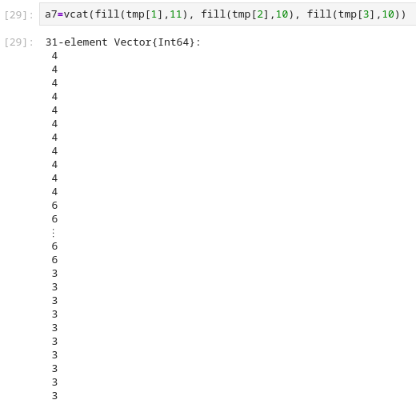

Рисунок 11: 3.7

## 3.8

Аналогично повторяю компоненты вектора tmp несколько раз по заданию (рис. 12)

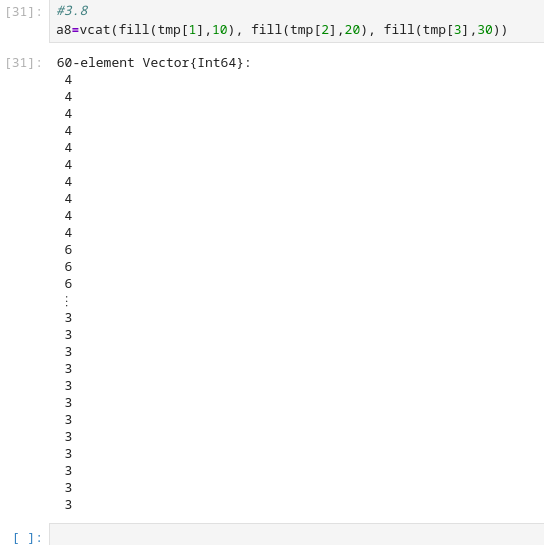

Рисунок 12: 3.8

## 3.9

Вывожу вектор, компоненты которого заданы степенной функцией (рис. 13)

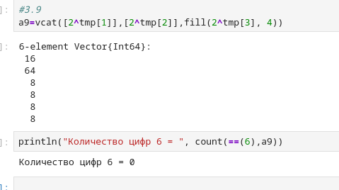

Рисунок 13: 3.9

## 3.10

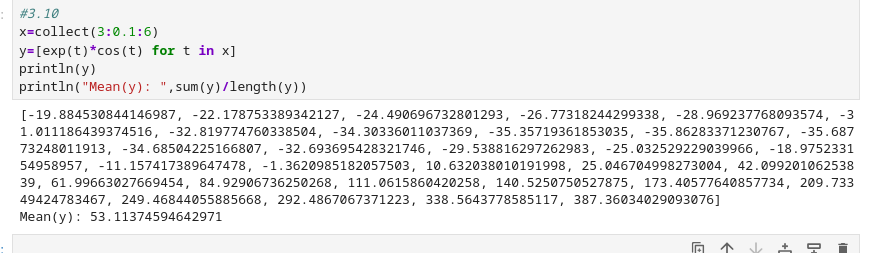

Рисунок 14: 3.10

## 3.11

Вывожу вектор вида (𝑥𝑖, 𝑦𝑗) с узлами в заданных точках по заданию (рис. 15)

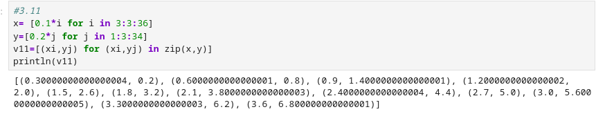

Рисунок 15: 3.11

## 3.12

Вывожу вектор с элементами вида 2i/i с заданными точками(рис. 16)

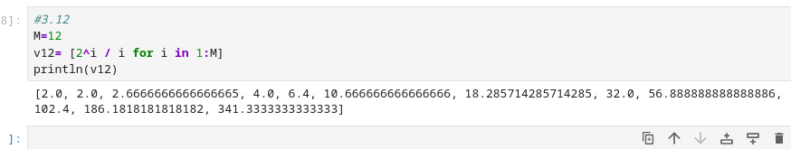

Рисунок 16: 3.12

## 3.13

Вывожу вектор вида fni со значениями от 1 до 30 (рис. 17)

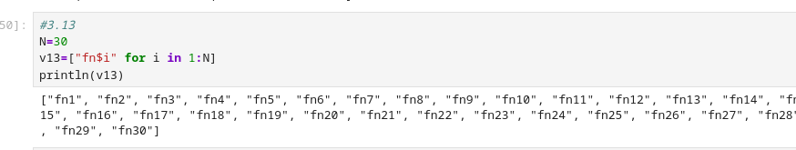

Рисунок 17: 3.13

## 3.14

Вывожу векторы 𝑥 = (𝑥1, 𝑥2, … , 𝑥𝑛) и 𝑦 = (𝑦1, 𝑦2, … , 𝑦𝑛) целочисленного типа длины 𝑛 = 250 как случайные выборки из совокупности 0, 1, … , 999 (рис. 18).

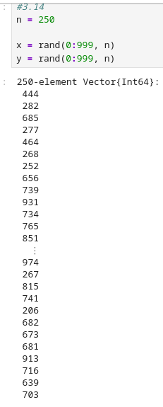

Рисунок 18: 3.14

## 3.14

Формирую вектор (𝑦2 − 𝑥1, … , 𝑦𝑛 − 𝑥𝑛−1), вектор с косинусами и синусами и вектор суммы (рис. 19)

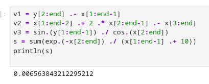

Рисунок 19: 3.14

## 3.14

Выбераю элементы вектора 𝑦, значения которых больше 600 и определяю индексы эолементов (рис. 20)

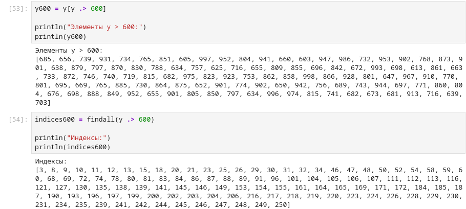

Рисунок 20: 3.14

## 3.14

Определяю значения вектора 𝑥, соответствующие значениям вектора 𝑦, значения которых больше 600 и в следующем пункте формирую вектор из средний значений компонент вектора (рис. 21).

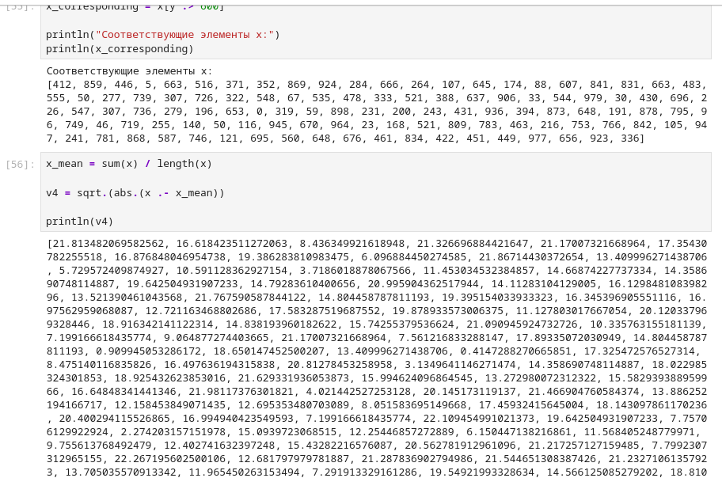

Рисунок 21: 3.14

## 3.14

Определяю, сколько элементов вектора 𝑦 отстоят от максимального значения не более, чем на 200; чётныe и нечётныe элементы вектора; сколько элементов кратны 7 и сортирую элементы 𝑥 в порядке возрастания элементов 𝑦 (рис. 22) (рис. 23)

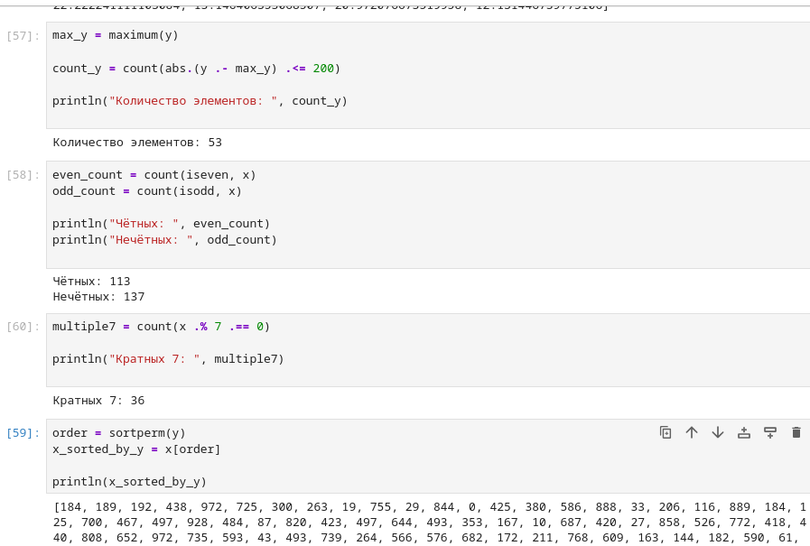

Рисунок 22: 3.14

## 3.14

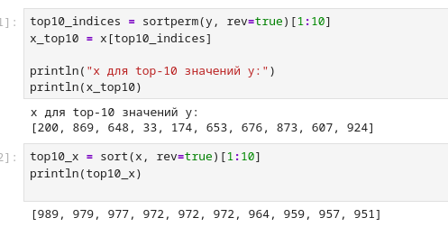

Рисунок 23: 3.14

## 3.14

Вывожу вектор только с уникальными значениями этого вектора (рис. 24)

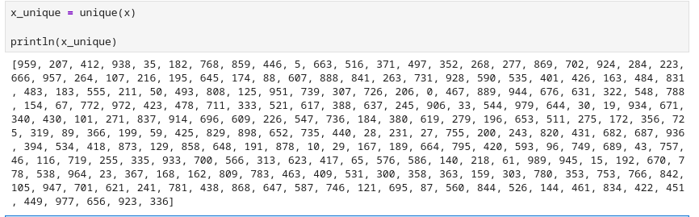

Рисунок 24: 3.14

## 4

Создаю массив squares, в котором будут храниться квадраты всех целых чисел от 1 до 100 (рис. 25)

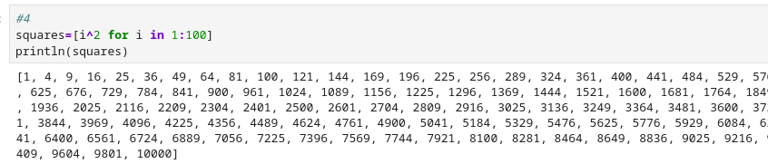

Рисунок 25: 4

## 5

[figure not shown]

Рисунок 26: 5

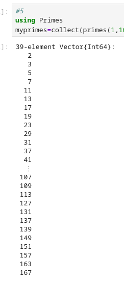

Рисунок 27: 5

## 6

Определяю 89 наименьшее простое число (рис. 28)

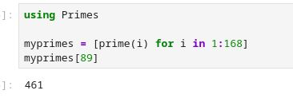

Рисунок 28: 6

## 6

Получаю срез массива от 89 до 99 элемента, содержащих наименьшие простые числа (рис. 29)

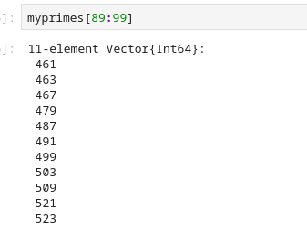

Рисунок 29: 6

## 6

Вычисляю выражения (рис. 30)

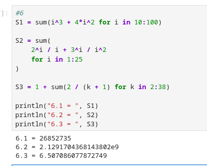

Рисунок 30: 6

# Выводы

В результате получился ipynb файл с выполненными заданиями на языке Julia, выполняя которые мы получили навыки работы с языком программирования и структурами данных в среде программирования JupyterLab